# Curation of motifs

Melanie (1028-02098-001-001)

September 04, 2026

# Introduction

The goal of this analysis is to:

1. Showcase key motifs found by all binding models.
2. Collect and filter motifs.
3. Merge relevant motifs into sets for downstream analysis.
4. Visualize motif summaries and representations.

# Computational Setup

```r
#Standard packages
library(rtracklayer) ; library(GenomicRanges); library(magrittr) ; library(Biostrings)
library(ggplot2) ; library(reshape2); library(plyranges); library(Rsamtools); library(parallel)
library(dplyr); library(data.table); library(patchwork); library(readr); library(testit)

#KNITR Options
setwd("/n/projects/mw2098/collaboration/for_carlos/20260205_manuscript/2_modeling/")
figure_filepath<-'figures/5_curate_motifs'
options(knitr.figure_dir=figure_filepath)

#Lab sources
source("scripts/r/granges_common.r")
source("scripts/r/metapeak_common.r")
source("scripts/r/knitr_common.r")
source("scripts/r/caching.r")
source("scripts/r/metapeak_functions.r")
source("scripts/r/motif_functions.r")

#Specific sources
library(BSgenome.Dmelanogaster.UCSC.dm6)
library(TxDb.Dmelanogaster.UCSC.dm6.ensGene)
library(ggseqlogo)

#Pre-existing variables
threads <- 5
dir.create('bed/mapped_motifs', recursive = T, showWarnings = F)
dir.create('tsv/mapped_motifs', recursive = T, showWarnings = F)
dir.create('rdata/mapped_motifs', recursive = T, showWarnings = F)
bsgenome<-BSgenome.Dmelanogaster.UCSC.dm6
txdb<-TxDb.Dmelanogaster.UCSC.dm6.ensGene

#variable/model information
output_length<-1000
bg_freqs<-c(.27, .21, .21, .27)
```

# Define motifs

Many motifs were found to be contributing but we will focus on the key specific motifs that produce precise TF footprinting. Please reference the `modiscolite` folder for more information and reports on all motifs.

```r
motifs.list<-list(
  s2_anthox6a_pbx_flag_nexus_fold1_pbx_counts=list('pattern_1'=c('AntHox6a-PBX', 'pos')),
  s2_anthox6a_pbx_ha_nexus_fold1_pbx_counts=list('pattern_0'=c('AntHox6a-PBX', 'pos')),

  s2_anthox1a_pbx_flag_nexus_fold1_pbx_counts=list('pattern_2'=c('AntHox1a-PBX', 'pos')),
  s2_anthox1a_pbx_ha_nexus_fold1_pbx_counts=list('pattern_5'=c('AntHox1a-PBX', 'neg')),

  s2_dfd_hth_exd_nexus_fold1_dfd_counts = list('pattern_1' = c('Dfd-Hth-Exd', 'neg')),
  s2_dfd_hth_ha_nexus_fold1_dfd_counts = list('pattern_0' = c('TTAATGGC', 'pos'))
)
```

# Import hits

Import all hits from the key motifs of interest.

```r
hits.list<-lapply(names(motifs.list), function(x){
  message(x)
  info.df<-data.frame(pattern_name = names(motifs.list[[x]]), motif =  motifs.list[[x]][[1]][1], oriented_strand = motifs.list[[x]][[1]][2])

  hits.df<-paste0('modiscolite/', x, '/hits.tsv') %>% readr::read_tsv(.)
  hits_filtered.df<-hits.df %>%
    dplyr::mutate(model = x) %>%
    dplyr::filter(pattern_name %in% names(motifs.list[[x]]), metacluster_name == 'pos_patterns') %>%
    dplyr::left_join(info.df) %>%
    as.data.frame
  print(table(hits_filtered.df$motif))
  return(hits_filtered.df)
})
```

```
##
## AntHox6a-PBX
##        27095
```

```
##
## AntHox6a-PBX
##       152586
```

```
##
## AntHox1a-PBX
##        34581
```

```
##
## AntHox1a-PBX
##         4520
```

```
##
## Dfd-Hth-Exd
##       19142
```

```
##
## TTAATGGC
##   132281
```

```r
names(hits.list)<-names(motifs.list)
```

# Curate motifs redundancy

Remove the following redundancies:

- Motifs that are peak-redundant will be mapped across peak “indexes” that are actually located across overlapping genomic regions.
  - In this case, we are mapping genome-wide, so this step isn’t necessary for this exact reason, but we will leave it in because I’m paranoid.
- Motifs that are palindromic will be mapped on the positive and negative strand with almost identical ranges.
  - Here, we will remove redundantly mapped motifs and select the unique motif maps that have the highest contribution.

In order to simultaneously manage peak-redundancy and palindromic motifs, we will make miniature islands for each motif group to reduce them.

```r
hits_dedup.list<-lapply(names(hits.list), function(modisco_name){
  #Orient strand to match desired aligned convention
  gr<-makeGRangesFromDataFrame(hits.list[[modisco_name]], keep.extra.columns = T, starts.in.df.are.0based = T) %>%
    plyranges::mutate(strand = ifelse(oriented_strand == 'neg',
                                      ifelse(strand == '-', '+', '-'),
                                      strand))

  #Import peaks and reduce them to a deduplicated state to get general peak regions.
  peaks.gr<-gr %>%
    GenomicRanges::reduce(., ignore.strand = T) %>%
    plyranges::mutate(region_id_tmp = 1:length(.))

  #Find overlaps between motifs and peaks
  ov<-findOverlaps(gr, peaks.gr, ignore.strand = T)

  #Assign temporary region ID for deduplication
  gr$region_id_tmp<-NA
  gr$region_id_tmp[ov@from]<-peaks.gr$region_id_tmp[ov@to]

  #Filter any motif that doesn't fit into peaks. These would be weird outliers, shouldn't happen, tbh.
  gr<-gr %>% plyranges::filter(!is.na(gr$region_id_tmp))

  #Deduplicate any motifs for palindromic mappings
  dedup.gr<-lapply(unique(gr$motif), function(y){
    print(y)
    motifs.gr<-gr %>% plyranges::filter(motif==y)
    motifs_dedup.gr<-remove_palindromic_motifs_from_bpnet_instances(dfi = motifs.gr,
                                                                    pattern_to_filter = y,
                                                                    chrom_name = 'seqnames', start_name = 'start', end_name = 'end',
                                                                    value_name = 'contrib_match', motif_name = 'motif',
                                                                    region_name = 'region_id_tmp')
    print(paste0(length(motifs_dedup.gr) , ' kept from ', length(motifs.gr)))
    return(motifs_dedup.gr)
  }) %>% as('GRangesList') %>% unlist(.)
  return(dedup.gr)
})
```

```
## [1] "AntHox6a-PBX"
```

```
## [1] "20732 kept from 27095"
## [1] "AntHox6a-PBX"
```

```
## [1] "106715 kept from 152586"
## [1] "AntHox1a-PBX"
```

```
## [1] "27372 kept from 34581"
## [1] "AntHox1a-PBX"
```

```
## [1] "3524 kept from 4520"
## [1] "Dfd-Hth-Exd"
```

```
## [1] "13019 kept from 19142"
## [1] "TTAATGGC"
```

```
## [1] "115721 kept from 132281"
```

```r
names(hits_dedup.list)<-names(hits.list)
```

Unwrap hits from a list.

```r
hits.gr<-hits_dedup.list %>% as('GRangesList') %>% unlist()
names(hits.gr)<-NULL
```

Format the motifs.

```r
all_motifs.gr<-hits.gr %>%
  plyranges::mutate(motif_id = 0:(length(.)-1), #0-based indexing later might come in handy
                    seq = getSeq(bsgenome, ., as.character = T))
```

# Export curated motifs

Show final results of motifs returned:

```r
table(all_motifs.gr$motif, all_motifs.gr$model)
```

```
##
##                s2_anthox1a_pbx_flag_nexus_fold1_pbx_counts
##   AntHox1a-PBX                                       27372
##   AntHox6a-PBX                                           0
##   Dfd-Hth-Exd                                            0
##   TTAATGGC                                               0
##
##                s2_anthox1a_pbx_ha_nexus_fold1_pbx_counts
##   AntHox1a-PBX                                      3524
##   AntHox6a-PBX                                         0
##   Dfd-Hth-Exd                                          0
##   TTAATGGC                                             0
##
##                s2_anthox6a_pbx_flag_nexus_fold1_pbx_counts
##   AntHox1a-PBX                                           0
##   AntHox6a-PBX                                       20732
##   Dfd-Hth-Exd                                            0
##   TTAATGGC                                               0
##
##                s2_anthox6a_pbx_ha_nexus_fold1_pbx_counts
##   AntHox1a-PBX                                         0
##   AntHox6a-PBX                                    106715
##   Dfd-Hth-Exd                                          0
##   TTAATGGC                                             0
##
##                s2_dfd_hth_exd_nexus_fold1_dfd_counts
##   AntHox1a-PBX                                     0
##   AntHox6a-PBX                                     0
##   Dfd-Hth-Exd                                  13019
##   TTAATGGC                                         0
##
##                s2_dfd_hth_ha_nexus_fold1_dfd_counts
##   AntHox1a-PBX                                    0
##   AntHox6a-PBX                                    0
##   Dfd-Hth-Exd                                     0
##   TTAATGGC                                   115721
```

```r
#1-based
motifs.df<-all_motifs.gr %>% as.data.frame()
readr::write_tsv(motifs.df, paste0('tsv/mapped_motifs/all_instances_curated_1based.tsv.gz'))

#0-based
lapply(names(hits_dedup.list), function(x){
  message(x)
  all_motifs.gr %>% plyranges::filter(model==x) %>% plyranges::mutate(name = motif) %>%
    rtracklayer::export(.,
                        paste0('bed/mapped_motifs/all_instances_curated_', x, '_0based.bed'))
})
```

```
## [[1]]
## BEDFile object
## resource: bed/mapped_motifs/all_instances_curated_s2_anthox6a_pbx_flag_nexus_fold1_pbx_counts_0based.bed
##
## [[2]]
## BEDFile object
## resource: bed/mapped_motifs/all_instances_curated_s2_anthox6a_pbx_ha_nexus_fold1_pbx_counts_0based.bed
##
## [[3]]
## BEDFile object
## resource: bed/mapped_motifs/all_instances_curated_s2_anthox1a_pbx_flag_nexus_fold1_pbx_counts_0based.bed
##
## [[4]]
## BEDFile object
## resource: bed/mapped_motifs/all_instances_curated_s2_anthox1a_pbx_ha_nexus_fold1_pbx_counts_0based.bed
##
## [[5]]
## BEDFile object
## resource: bed/mapped_motifs/all_instances_curated_s2_dfd_hth_exd_nexus_fold1_dfd_counts_0based.bed
##
## [[6]]
## BEDFile object
## resource: bed/mapped_motifs/all_instances_curated_s2_dfd_hth_ha_nexus_fold1_dfd_counts_0based.bed
```

Examine how many motifs show different sequences.

```r
all_motifs.gr %>%
  as.data.frame %>%
  dplyr::group_by(model, motif) %>%
  dplyr::slice_max(order_by = contrib_match, n = 250) %>%
  dplyr::summarize(TGATTAAT = sum(grepl('TGATTAAT', seq)),
                   TGATTGAT = sum(grepl('TGATTGAT', seq)),
                   total_motifs = dplyr::n())
```

```
## # A tibble: 6 × 5
## # Groups:   model [6]
##   model                                     motif TGATTAAT TGATTGAT total_motifs
##   <chr>                                     <chr>    <int>    <int>        <int>
## 1 s2_anthox1a_pbx_flag_nexus_fold1_pbx_cou… AntH…        6       79          250
## 2 s2_anthox1a_pbx_ha_nexus_fold1_pbx_counts AntH…        4       21          250
## 3 s2_anthox6a_pbx_flag_nexus_fold1_pbx_cou… AntH…        0      208          250
## 4 s2_anthox6a_pbx_ha_nexus_fold1_pbx_counts AntH…        0      193          250
## 5 s2_dfd_hth_exd_nexus_fold1_dfd_counts     Dfd-…      204       44          250
## 6 s2_dfd_hth_ha_nexus_fold1_dfd_counts      TTAA…        0        0          250
```

# Visualize PWMs and CWMs from TF-MoDISco

```r
# system(paste0('rm ', figure_filepath, '/unaligned_seqlets/seqlet_logo_*'))

#Plot all seqlet PWM and CWM logos
pwm_and_cwm.logo.list<-lapply(all_motifs.gr$model %>% unique, function(x){

  info.df<-data.frame(pattern_name = names(motifs.list[[x]]), motif =  motifs.list[[x]][[1]][1], oriented_strand = motifs.list[[x]][[1]][2])

  s.hdf5<-rhdf5::h5read(paste0('modiscolite/', x, '/modisco.h5'),
                        paste0('pos_patterns/', info.df$pattern_name))
  cwm<-s.hdf5$contrib_scores
  pwm<-ppm_to_ic(s.hdf5$sequence, bg_freq = c(.3, .2, .2, .3))

  #Orient strand
  if(info.df$oriented_strand=='neg'){
    cwm<-cwm[nrow(cwm):1,ncol(cwm):1]
    pwm<-pwm[nrow(pwm):1,ncol(pwm):1]
  }

  rownames(cwm)<-c('A','C','G','T')
  rownames(pwm)<-c('A','C','G','T')
  pwm_and_cwm.list<-list(pwm = pwm, cwm = cwm)
  y_prefix<-paste0(x %>% gsub('_fold1', '', .) %>% gsub('_pbx_counts', '', .) %>% gsub('_dfd_counts', '', .))
  names(pwm_and_cwm.list)<-paste0(y_prefix, c('_pwm', '_cwm'))

  pwm_and_cwm.logo<-ggseqlogo(pwm_and_cwm.list, method='custom', seq_type='dna') +
    facet_wrap(~seq_group, nrow = 1, scales='free') +
    theme(axis.text.x = element_blank())

  return(pwm_and_cwm.logo)
})

pwm_and_cwm_all.logo<-wrap_plots(pwm_and_cwm.logo.list, ncol = 1)
ggsave(paste0(figure_filepath, '/seqlet_logos.png'), pwm_and_cwm_all.logo, height = 8, width = 10)
ggsave(paste0(figure_filepath, '/seqlet_logos.pdf'), pwm_and_cwm_all.logo, height = 8, width = 10)
```

# Visualize ChIP-nexus coverage

Given the set of motifs, what do ChIP-nexus heatmaps look like across the top motifs per logo?

## Allocate coverage and settings

```r
nexus_bw.list<-list(
  S2_AntHOX6a_PBX_Flag = list(pos = 'bw/S2_AntHOX6a_PBX_Flag_nexus_combined_positive.bw',
                              neg = 'bw/S2_AntHOX6a_PBX_Flag_nexus_combined_negative.bw') %>%
    mclapply(., function(x) {rtracklayer::import.bw(x, as="RleList")}, mc.cores = 2),
  S2_AntHOX6a_PBX_HA = list(pos = 'bw/S2_AntHOX6a_PBX_HA_nexus_combined_positive.bw',
                            neg = 'bw/S2_AntHOX6a_PBX_HA_nexus_combined_negative.bw') %>%
    mclapply(., function(x) {rtracklayer::import.bw(x, as="RleList")}, mc.cores = 2),

  S2_AntHOX1a_PBX_Flag = list(pos = 'bw/S2_AntHOX1a_PBX_Flag_nexus_combined_positive.bw',
                              neg = 'bw/S2_AntHOX1a_PBX_Flag_nexus_combined_negative.bw') %>%
    mclapply(., function(x) {rtracklayer::import.bw(x, as="RleList")}, mc.cores = 2),
  S2_AntHOX1a_PBX_HA = list(pos = 'bw/S2_AntHOX1a_PBX_HA_nexus_combined_positive.bw',
                            neg = 'bw/S2_AntHOX1a_PBX_HA_nexus_combined_negative.bw') %>%
    mclapply(., function(x) {rtracklayer::import.bw(x, as="RleList")}, mc.cores = 2)

  # S2_Dfd_Hth_HA = list(pos = 'bw/S2_Dfd_Hth_HA_nexus_combined_positive.bw',
  #                      neg = 'bw/S2_Dfd_Hth_HA_nexus_combined_negative.bw') %>%
  #   mclapply(., function(x) {rtracklayer::import.bw(x, as="RleList")}, mc.cores = 2),
  # S2_Dfd_Hth_anti_EXD = list(pos = 'bw/S2_Dfd_Hth_anti_EXD_nexus_combined_positive.bw',
  #                             neg = 'bw/S2_Dfd_Hth_anti_EXD_nexus_combined_negative.bw') %>%
  #   mclapply(., function(x) {rtracklayer::import.bw(x, as="RleList")}, mc.cores = 2)
  )

nexus_norm_bw.list<-list(
  S2_AntHOX6a_PBX_Flag = list(pos = 'bw/S2_AntHOX6a_PBX_Flag_nexus_combined_normalized_positive.bw',
                              neg = 'bw/S2_AntHOX6a_PBX_Flag_nexus_combined_normalized_negative.bw') %>%
    mclapply(., function(x) {rtracklayer::import.bw(x, as="RleList")}, mc.cores = 2),
  S2_AntHOX6a_PBX_HA = list(pos = 'bw/S2_AntHOX6a_PBX_HA_nexus_combined_normalized_positive.bw',
                            neg = 'bw/S2_AntHOX6a_PBX_HA_nexus_combined_normalized_negative.bw') %>%
    mclapply(., function(x) {rtracklayer::import.bw(x, as="RleList")}, mc.cores = 2),

  S2_AntHOX1a_PBX_Flag = list(pos = 'bw/S2_AntHOX1a_PBX_Flag_nexus_combined_normalized_positive.bw',
                              neg = 'bw/S2_AntHOX1a_PBX_Flag_nexus_combined_normalized_negative.bw') %>%
    mclapply(., function(x) {rtracklayer::import.bw(x, as="RleList")}, mc.cores = 2),
  S2_AntHOX1a_PBX_HA = list(pos = 'bw/S2_AntHOX1a_PBX_HA_nexus_combined_normalized_positive.bw',
                            neg = 'bw/S2_AntHOX1a_PBX_HA_nexus_combined_normalized_negative.bw') %>%
    mclapply(., function(x) {rtracklayer::import.bw(x, as="RleList")}, mc.cores = 2)

  # S2_Dfd_Hth_HA = list(pos = 'bw/S2_Dfd_Hth_HA_nexus_combined_positive.bw',
  #                      neg = 'bw/S2_Dfd_Hth_HA_nexus_combined_negative.bw') %>%
  #   mclapply(., function(x) {rtracklayer::import.bw(x, as="RleList")}, mc.cores = 2),
  # S2_Dfd_Hth_anti_EXD = list(pos = 'bw/S2_Dfd_Hth_anti_EXD_nexus_combined_positive.bw',
  #                             neg = 'bw/S2_Dfd_Hth_anti_EXD_nexus_combined_negative.bw') %>%
  #   mclapply(., function(x) {rtracklayer::import.bw(x, as="RleList")}, mc.cores = 2)
)

#Define how many motifs to consider
top_n = 250
```

## Plot coverage

```r
hm_plot_all.list<-lapply(all_motifs.gr$model %>% unique, function(x){
  message(x)
  m.gr<-all_motifs.gr %>% plyranges::filter(model==x) %>% plyranges::arrange(desc(contrib_match)) %>%
    head(n=top_n) %>%
    plyranges::arrange(contrib_match)
  print(m.gr$seq %>% table %>% sort(decreasing = T))

  plots_across_motif.list<-mclapply(names(nexus_bw.list), function(y){
    nexus.df<-plot_nexus_heatmap(regions.gr = GenomicRanges::resize(m.gr, width = 1, fix = 'center'),
                                   sample = nexus_bw.list[[y]], upstream = 150, downstream = 151,
                                   title = y, order = 'asis', removal_threshold = .8, normalize_threshold = .999,
                                   return_only_df = T) #.8, .99

    nexus.plot<-ggplot()+
      geom_tile(data=nexus.df %>% dplyr::filter(strand == 'pos'), aes(x=position, y=region, fill=signal))+
      geom_tile(data=nexus.df %>% dplyr::filter(strand == 'neg'), aes(x=position, y=region, fill=-signal), alpha=.5)+
      ggtitle(paste0('Motif: ', m.gr$motif %>% unique, '\nfrom model\n', x), subtitle = paste0('ChIP: ', y))+
      scale_x_continuous("Position (bp)", expand = c(0, 0))+
      scale_y_continuous("Regions", expand = c(0, 0))+
      scale_fill_gradientn(colors = c('#08306b', '#08519c' , '#2171b5', '#4292c6', '#6baed6',
                                      '#9ecae1', '#c6dbef','#deebf7', '#f7fbff', "white",
                                      '#fff5f0','#fee0d2','#fcbba1','#fc9272','#fb6a4a',
                                      '#ef3b2c','#cb181d','#a50f15','#67000d'), name = "norm. signal") +
      # scale_fill_gradientn(colors = c('#08306b', '#08519c' , '#2171b5', '#c6dbef','#deebf7', '#f7fbff',
      #                                 "white",
      #                                 '#fff5f0','#fee0d2','#fcbba1','#cb181d','#a50f15','#67000d'), name = "norm. signal") +
      theme_classic()+
      theme(text=element_text(size=14), panel.grid = element_blank(), panel.border = element_blank())
    return(nexus.plot)
  }, mc.cores = 4)

  hm.plot<-wrap_plots(plots_across_motif.list, nrow = 1)
  return(hm.plot)
})
```

```
## .
## ATGATTGATG TTGATTGATG CTGATTGATG GTGATTGATG ATGATTGATT TTGATGGATG TTGATTGATT
##         57         45         26         26         21          8          8
## ATGATGGATG GTGATTGATA CTGATGGATG CTGATTGATT GTGATTGATT ATGATTGATC GTGATGGATG
##          7          6          5          5          5          3          3
## ATGACTGATG ATGATCGATG ATGATGGATC CTGATCGATG GTGAGTGATG GTGATCGATG TTGATTGATC
##          2          2          2          2          2          2          2
## ATGACCGATG ATGATAGATG ATGATTGAGG ATGATTGATA CTGATAGATG CTGATTGATA GTGATCGATC
##          1          1          1          1          1          1          1
## GTGATCGATT GTGATTGATC TTGATCGATG TTGATTGATA
##          1          1          1          1
## [1] 250
## [1] 250
## [1] 250
## [1] 250
```

```
## .
## TTGATTGATT ATGATTGATT TTGATTGATG ATGATTGATG ATGATCGATG GTGATTGATT ATGATTGATC
##         37         28         28         26         19         14         11
## CTGATTGATT ATGATCGATT ATGATTGATA GTGATTGATG TTGATCGATG TTGATCGATT CTGATTGATG
##          9          8          8          7          7          7          6
## GTGATCGATG GTGATTGATC TTGATCGATA CTGATTGATC TTGATTGATA ATGATCGATA GTGATTGATA
##          5          5          5          4          4          3          3
## TTGATTGATC GTGATCGATT TTGATCGATC
##          3          2          1
## [1] 250
## [1] 250
## [1] 250
## [1] 250
```

```
## .
## ATGATTTATGG ATGATTGATGG GTGATTTATCT GTGATTTATGG ATGATTGATGA ATGATTTATGA
##          15          14          13          11          10          10
## TTGATTTATGA TTGATTTATGG ATGATTTATGT GTGATTTATGA ATGATTTATCA ATGATTTATTG
##           9           8           7           7           6           6
## CTGATTTATGG TTGATTTATGT ATGATTGATCA ATGATTGATGT CTGATTTATGA CTGATTTATGT
##           6           6           5           5           5           5
## GTGATTGATGA GTGATTGATGG ATGATTTATGC CTGATTGATGG GTGATTGATGT GTGATTTATCA
##           5           5           4           4           4           4
## GTGATTTATGC GTGATTTATTA TTGATTGATGG ATGATTGATCT ATGATTTATCT ATGATTTATTA
##           4           4           4           3           3           3
## ATGATTTATTT CTGATTGATCA GTGATTTATGT GTGATTTATTT TTGATTGATGA TTGATTTATCA
##           3           3           3           3           3           3
## TTGATTTATCT ATGATTGATTG CTGATTGATGA CTGATTTATCT GTGATTAATGT GTGATTGATCT
##           3           2           2           2           2           2
## GTGATTTATTG TTGATTGATCA TTGATTGATCT TTGATTTATTT ATGATTAATGA ATGATTAATGG
##           2           2           2           2           1           1
## ATGATTCATCG ATGATTGATCG ATGATTTATAG ATGATTTATAT CTGATTAATCT CTGATTGATCT
##           1           1           1           1           1           1
## CTGATTGATGT CTGATTTATCA CTGATTTATGC CTGATTTATTA CTGATTTATTG GTGATTAATGA
##           1           1           1           1           1           1
## GTGATTGATCA GTGATTTATAT
##           1           1
## [1] 250
## [1] 250
## [1] 250
## [1] 250
```

```
## .
## ATGATTTATGGCC ATGATTTATGGCA TTGATTTATGGCA ATGATTTATGGCG TTGATTTATGGCC
##            29            20            12            11            10
## ATGATTTATGGCT TTGATTTATGGCT GTGATTTATGGCA TTGATTTATGGCG GTGATTTATGGCC
##             9             9             8             8             7
## CTGATTTATGGCC ATGATTGATGGCT ATGATTTATGGGG GTGATTTATTGCC TTGATTGATGGCC
##             6             5             5             5             5
## CTGATTTATGGCG GTGATTTATGGCG GTGATTTATGTCC ATGATTGATGGCC ATGATTTATGGGC
##             4             4             4             3             3
## ATGATTTATGGGT ATGATTTATTGCC CTGATTTATGGCT GTGATTTATTGCA ATGATTAATGGCA
##             3             3             3             3             2
## ATGATTTATGACA ATGATTTATGACC ATGATTTATGCCG ATGATTTATGGAG ATGATTTATGGAT
##             2             2             2             2             2
## ATGATTTATGGGA ATGATTTATGTCG ATGATTTATTGCA ATGATTTATTGGC GTGATTGATGGCA
##             2             2             2             2             2
## GTGATTGATGGCC GTGATTTATGACA GTGATTTATGGAT GTGATTTATGGTA AAGATTTATGGCT
##             2             2             2             2             1
## ATGATTAATGGCC ATGATTAATGGCT ATGATTGATGGCA ATGATTGATTGCC ATGATTTATAGCC
##             1             1             1             1             1
## ATGATTTATGACG ATGATTTATGACT ATGATTTATGCCA ATGATTTATGCCC ATGATTTATGCCT
##             1             1             1             1             1
## ATGATTTATGGAA ATGATTTATGGAC ATGATTTATGGTT ATGATTTATGTCC CTGATTGATGGCA
##             1             1             1             1             1
## CTGATTTATGCCA CTGATTTATGGCA CTGATTTATGGGG GTGATTTATGACC GTGATTTATGGAA
##             1             1             1             1             1
## GTGATTTATGGAC GTGATTTATGGAG GTGATTTATGGCT GTGATTTATGGGA GTGATTTATGGGG
##             1             1             1             1             1
## GTGATTTATGGTG TTGATTGATGGCT TTGATTTATGACT TTGATTTATGGAG TTGATTTATGGAT
##             1             1             1             1             1
## TTGATTTATGGGA TTGATTTATGGGC TTGATTTATGGGG TTGATTTATGGTA TTGATTTATGGTC
##             1             1             1             1             1
## TTGATTTATGGTG TTGATTTATGGTT TTGATTTATGTCC TTGATTTATTGCA TTGATTTATTGCT
##             1             1             1             1             1
## [1] 250
## [1] 250
## [1] 250
## [1] 250
```

```
## .
## ATGATTAATGGC ATGATTAATTAC ATGATTAATGAG GTGATTAATTAA GTGATTAATTAT TTGATTAATGAA
##            8            7            6            6            6            6
## ATGATTAATGAA ATGATTAATTAT GTGATTAATTAG GTGATTGATGGC TTGATTAATTAT ATGATTAATGTC
##            5            5            5            5            5            4
## ATGATTAATTAA ATGATTAATTAG GTGATTAATCAC GTGATTAATGAA GTGATTGATGAC GTGATTGATGAG
##            4            4            4            4            4            4
## TTGATTAATTAA TTGATTAATTAC ATGATTAATAAT ATGATTAATCAC CTGATTAATCAG CTGATTAATCTG
##            4            4            3            3            3            3
## CTGATTAATGAA GTGATTAATCAA GTGATTAATGAC GTGATTAATGAG GTGATTAATGAT GTGATTAATGGC
##            3            3            3            3            3            3
## GTGATTAATTAC GTGATTAATTTG GTGATTGATGAT TTGATTAATGTG ATGATTAATAAC ATGATTAATCAA
##            3            3            3            3            2            2
## ATGATTAATCAG ATGATTAATGAT ATGATTAATGGG ATGATTAATGTG ATGATTAATTGG CTGATTAATGTG
##            2            2            2            2            2            2
## CTGATTAATTAC CTGATTAATTAT GTGATTAATAAT GTGATTAATCGC GTGATTAATGGT GTGATTAATGTA
##            2            2            2            2            2            2
## GTGATTAATTGG GTGATTGATCAT GTGATTGATGGA GTGATTGATGGG GTGATTGATGTG GTGATTGATTAG
##            2            2            2            2            2            2
## TTGATTAATAAC TTGATTAATGAC TTGATTAATGGA TTGATTAATGGC TTGATTAATGGT TTGATTAATTGC
##            2            2            2            2            2            2
## ATGATTAATAAA ATGATTAATAAG ATGATTAATCAT ATGATTAATCTG ATGATTAATGAC ATGATTAATGGA
##            1            1            1            1            1            1
## ATGATTAATGGT ATGATTAATGTT ATGATTAATTGC ATGATTAATTGT ATGATTGATCAC ATGATTGATGAA
##            1            1            1            1            1            1
## ATGATTGATGGC ATGATTGATTAC ATGATTTATGAG CTGATTAATAAT CTGATTAATCGC CTGATTAATGAG
##            1            1            1            1            1            1
## CTGATTAATGGA CTGATTAATGGG CTGATTAATTAA CTGATTAATTAG CTGATTAATTGA CTGATTAATTGC
##            1            1            1            1            1            1
## CTGATTAATTGG CTGATTGATGTA GTGATTAATCAT GTGATTAATCGA GTGATTAATGGG GTGATTAATGTG
##            1            1            1            1            1            1
## GTGATTAATGTT GTGATTAATTGC GTGATTAATTTT GTGATTGATCAC GTGATTGATCGA GTGATTGATGAA
##            1            1            1            1            1            1
## GTGATTGATGGT GTGATTGATGTC GTGATTGATGTT GTGATTGATTAC GTGATTGATTTC GTGATTTATGAG
##            1            1            1            1            1            1
## TTGATTAATAAA TTGATTAATCAA TTGATTAATCGG TTGATTAATGAG TTGATTAATGAT TTGATTAATGTT
##            1            1            1            1            1            1
## TTGATTAATTAG TTGATTAATTGT TTGATTAATTTA TTGATTGATGAC TTGATTGATGAG TTGATTGATGAT
##            1            1            1            1            1            1
## TTGATTGATGGC TTGATTGATGTC
##            1            1
## [1] 250
## [1] 250
## [1] 250
## [1] 250
```

```
## .
## TTAATGGC TTAATGAC CTAATGGC CTAATGAC
##      192       30       17       11
## [1] 250
## [1] 250
## [1] 250
## [1] 250
```

```r
hm_all.plot<-wrap_plots(hm_plot_all.list, ncol = 1)
ggsave(paste0(figure_filepath, '/nexus_heatmap_across_all_motifs.png'), hm_all.plot, dpi = 720, height = 24, width = 16)
ggsave(paste0(figure_filepath, '/nexus_heatmap_across_all_motifs.pdf'), hm_all.plot, height = 24, width = 16)
```

Plot metapeaks as well

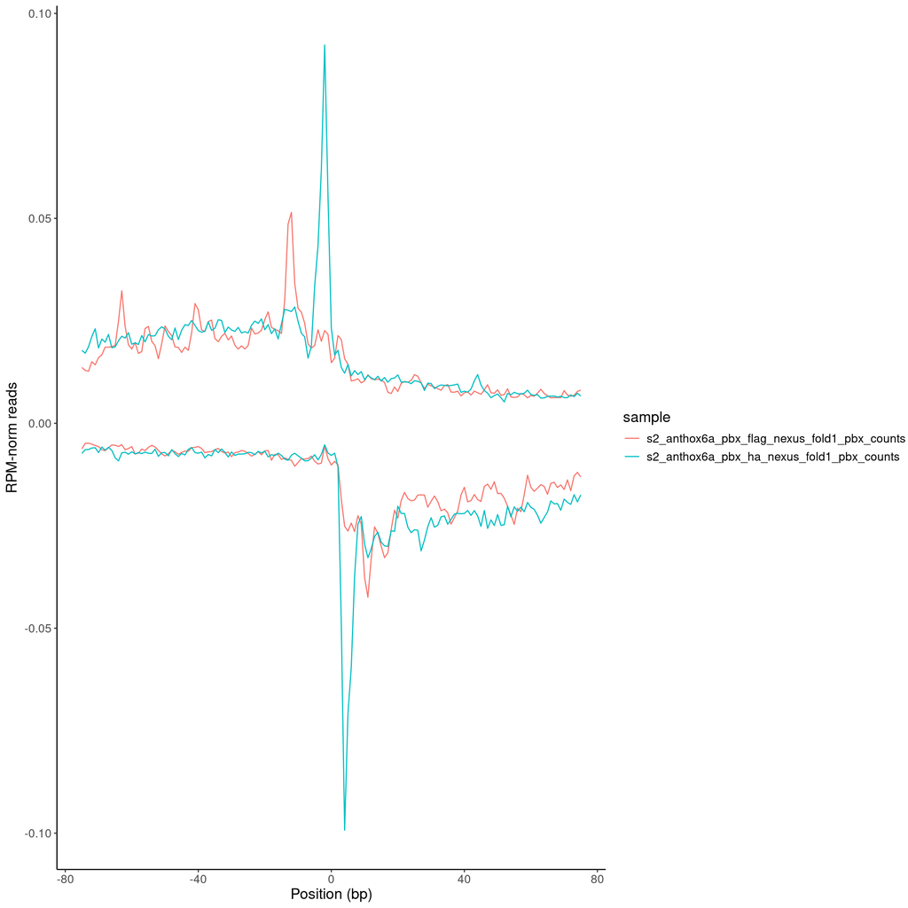

```r
mp.df<-lapply(all_motifs.gr$model %>% unique %>% grep('anthox6', ., value = T), function(x){
  message(x)
  pertinent_nexus_sample<-tolower(x) %>% gsub('_nexus_fold1_pbx_counts', '', .)
  bw<-nexus_norm_bw.list[[names(nexus_norm_bw.list)[grepl(pertinent_nexus_sample, names(nexus_norm_bw.list), ignore.case = T)]]]

  m.gr<-all_motifs.gr %>% plyranges::filter(model==x) %>% plyranges::arrange(desc(contrib_match)) %>%
    head(n=top_n) %>%
    plyranges::arrange(contrib_match)

  df<-exo_metapeak(GenomicRanges::resize(m.gr, width = 1, fix = 'center'), bw, upstream = 75, downstream = 76) %>%
    dplyr::mutate(sample = x)
  return(df)
}) %>% rbindlist()

mp.plot<-ggplot(data = mp.df, aes(x = tss_distance, y = reads, group = interaction(strand, sample), color = sample))+
  geom_line()+
  scale_x_continuous("Position (bp)")+
  scale_y_continuous("RPM-norm reads")+
  theme_classic()+
  theme(text=element_text(size=14), panel.grid = element_blank(), panel.border = element_blank())
mp.plot
```

```r
ggsave(paste0(figure_filepath, '/nexus_mp_across_anthox6a_motifs.png'), mp.plot, dpi = 720, height = 6, width = 8)
ggsave(paste0(figure_filepath, '/nexus_mp_across_anthox6a_motifs.pdf'), mp.plot, height = 6, width = 8)
```

Report underlying sequences.

```r
lapply(all_motifs.gr$model %>% unique, function(x){
  message(x)
  m.gr<-all_motifs.gr %>% plyranges::filter(model==x) %>% plyranges::arrange(desc(contrib_match)) %>%
    head(n=top_n) %>%
    plyranges::arrange(contrib_match)
  print(m.gr$seq %>% table %>% sort(decreasing = T)) %>% head(n=5)
})
```

```
## .
## ATGATTGATG TTGATTGATG CTGATTGATG GTGATTGATG ATGATTGATT TTGATGGATG TTGATTGATT
##         57         45         26         26         21          8          8
## ATGATGGATG GTGATTGATA CTGATGGATG CTGATTGATT GTGATTGATT ATGATTGATC GTGATGGATG
##          7          6          5          5          5          3          3
## ATGACTGATG ATGATCGATG ATGATGGATC CTGATCGATG GTGAGTGATG GTGATCGATG TTGATTGATC
##          2          2          2          2          2          2          2
## ATGACCGATG ATGATAGATG ATGATTGAGG ATGATTGATA CTGATAGATG CTGATTGATA GTGATCGATC
##          1          1          1          1          1          1          1
## GTGATCGATT GTGATTGATC TTGATCGATG TTGATTGATA
##          1          1          1          1
```

```
## .
## TTGATTGATT ATGATTGATT TTGATTGATG ATGATTGATG ATGATCGATG GTGATTGATT ATGATTGATC
##         37         28         28         26         19         14         11
## CTGATTGATT ATGATCGATT ATGATTGATA GTGATTGATG TTGATCGATG TTGATCGATT CTGATTGATG
##          9          8          8          7          7          7          6
## GTGATCGATG GTGATTGATC TTGATCGATA CTGATTGATC TTGATTGATA ATGATCGATA GTGATTGATA
##          5          5          5          4          4          3          3
## TTGATTGATC GTGATCGATT TTGATCGATC
##          3          2          1
```

```
## .
## ATGATTTATGG ATGATTGATGG GTGATTTATCT GTGATTTATGG ATGATTGATGA ATGATTTATGA
##          15          14          13          11          10          10
## TTGATTTATGA TTGATTTATGG ATGATTTATGT GTGATTTATGA ATGATTTATCA ATGATTTATTG
##           9           8           7           7           6           6
## CTGATTTATGG TTGATTTATGT ATGATTGATCA ATGATTGATGT CTGATTTATGA CTGATTTATGT
##           6           6           5           5           5           5
## GTGATTGATGA GTGATTGATGG ATGATTTATGC CTGATTGATGG GTGATTGATGT GTGATTTATCA
##           5           5           4           4           4           4
## GTGATTTATGC GTGATTTATTA TTGATTGATGG ATGATTGATCT ATGATTTATCT ATGATTTATTA
##           4           4           4           3           3           3
## ATGATTTATTT CTGATTGATCA GTGATTTATGT GTGATTTATTT TTGATTGATGA TTGATTTATCA
##           3           3           3           3           3           3
## TTGATTTATCT ATGATTGATTG CTGATTGATGA CTGATTTATCT GTGATTAATGT GTGATTGATCT
##           3           2           2           2           2           2
## GTGATTTATTG TTGATTGATCA TTGATTGATCT TTGATTTATTT ATGATTAATGA ATGATTAATGG
##           2           2           2           2           1           1
## ATGATTCATCG ATGATTGATCG ATGATTTATAG ATGATTTATAT CTGATTAATCT CTGATTGATCT
##           1           1           1           1           1           1
## CTGATTGATGT CTGATTTATCA CTGATTTATGC CTGATTTATTA CTGATTTATTG GTGATTAATGA
##           1           1           1           1           1           1
## GTGATTGATCA GTGATTTATAT
##           1           1
```

```
## .
## ATGATTTATGGCC ATGATTTATGGCA TTGATTTATGGCA ATGATTTATGGCG TTGATTTATGGCC
##            29            20            12            11            10
## ATGATTTATGGCT TTGATTTATGGCT GTGATTTATGGCA TTGATTTATGGCG GTGATTTATGGCC
##             9             9             8             8             7
## CTGATTTATGGCC ATGATTGATGGCT ATGATTTATGGGG GTGATTTATTGCC TTGATTGATGGCC
##             6             5             5             5             5
## CTGATTTATGGCG GTGATTTATGGCG GTGATTTATGTCC ATGATTGATGGCC ATGATTTATGGGC
##             4             4             4             3             3
## ATGATTTATGGGT ATGATTTATTGCC CTGATTTATGGCT GTGATTTATTGCA ATGATTAATGGCA
##             3             3             3             3             2
## ATGATTTATGACA ATGATTTATGACC ATGATTTATGCCG ATGATTTATGGAG ATGATTTATGGAT
##             2             2             2             2             2
## ATGATTTATGGGA ATGATTTATGTCG ATGATTTATTGCA ATGATTTATTGGC GTGATTGATGGCA
##             2             2             2             2             2
## GTGATTGATGGCC GTGATTTATGACA GTGATTTATGGAT GTGATTTATGGTA AAGATTTATGGCT
##             2             2             2             2             1
## ATGATTAATGGCC ATGATTAATGGCT ATGATTGATGGCA ATGATTGATTGCC ATGATTTATAGCC
##             1             1             1             1             1
## ATGATTTATGACG ATGATTTATGACT ATGATTTATGCCA ATGATTTATGCCC ATGATTTATGCCT
##             1             1             1             1             1
## ATGATTTATGGAA ATGATTTATGGAC ATGATTTATGGTT ATGATTTATGTCC CTGATTGATGGCA
##             1             1             1             1             1
## CTGATTTATGCCA CTGATTTATGGCA CTGATTTATGGGG GTGATTTATGACC GTGATTTATGGAA
##             1             1             1             1             1
## GTGATTTATGGAC GTGATTTATGGAG GTGATTTATGGCT GTGATTTATGGGA GTGATTTATGGGG
##             1             1             1             1             1
## GTGATTTATGGTG TTGATTGATGGCT TTGATTTATGACT TTGATTTATGGAG TTGATTTATGGAT
##             1             1             1             1             1
## TTGATTTATGGGA TTGATTTATGGGC TTGATTTATGGGG TTGATTTATGGTA TTGATTTATGGTC
##             1             1             1             1             1
## TTGATTTATGGTG TTGATTTATGGTT TTGATTTATGTCC TTGATTTATTGCA TTGATTTATTGCT
##             1             1             1             1             1
```

```
## .
## ATGATTAATGGC ATGATTAATTAC ATGATTAATGAG GTGATTAATTAA GTGATTAATTAT TTGATTAATGAA
##            8            7            6            6            6            6
## ATGATTAATGAA ATGATTAATTAT GTGATTAATTAG GTGATTGATGGC TTGATTAATTAT ATGATTAATGTC
##            5            5            5            5            5            4
## ATGATTAATTAA ATGATTAATTAG GTGATTAATCAC GTGATTAATGAA GTGATTGATGAC GTGATTGATGAG
##            4            4            4            4            4            4
## TTGATTAATTAA TTGATTAATTAC ATGATTAATAAT ATGATTAATCAC CTGATTAATCAG CTGATTAATCTG
##            4            4            3            3            3            3
## CTGATTAATGAA GTGATTAATCAA GTGATTAATGAC GTGATTAATGAG GTGATTAATGAT GTGATTAATGGC
##            3            3            3            3            3            3
## GTGATTAATTAC GTGATTAATTTG GTGATTGATGAT TTGATTAATGTG ATGATTAATAAC ATGATTAATCAA
##            3            3            3            3            2            2
## ATGATTAATCAG ATGATTAATGAT ATGATTAATGGG ATGATTAATGTG ATGATTAATTGG CTGATTAATGTG
##            2            2            2            2            2            2
## CTGATTAATTAC CTGATTAATTAT GTGATTAATAAT GTGATTAATCGC GTGATTAATGGT GTGATTAATGTA
##            2            2            2            2            2            2
## GTGATTAATTGG GTGATTGATCAT GTGATTGATGGA GTGATTGATGGG GTGATTGATGTG GTGATTGATTAG
##            2            2            2            2            2            2
## TTGATTAATAAC TTGATTAATGAC TTGATTAATGGA TTGATTAATGGC TTGATTAATGGT TTGATTAATTGC
##            2            2            2            2            2            2
## ATGATTAATAAA ATGATTAATAAG ATGATTAATCAT ATGATTAATCTG ATGATTAATGAC ATGATTAATGGA
##            1            1            1            1            1            1
## ATGATTAATGGT ATGATTAATGTT ATGATTAATTGC ATGATTAATTGT ATGATTGATCAC ATGATTGATGAA
##            1            1            1            1            1            1
## ATGATTGATGGC ATGATTGATTAC ATGATTTATGAG CTGATTAATAAT CTGATTAATCGC CTGATTAATGAG
##            1            1            1            1            1            1
## CTGATTAATGGA CTGATTAATGGG CTGATTAATTAA CTGATTAATTAG CTGATTAATTGA CTGATTAATTGC
##            1            1            1            1            1            1
## CTGATTAATTGG CTGATTGATGTA GTGATTAATCAT GTGATTAATCGA GTGATTAATGGG GTGATTAATGTG
##            1            1            1            1            1            1
## GTGATTAATGTT GTGATTAATTGC GTGATTAATTTT GTGATTGATCAC GTGATTGATCGA GTGATTGATGAA
##            1            1            1            1            1            1
## GTGATTGATGGT GTGATTGATGTC GTGATTGATGTT GTGATTGATTAC GTGATTGATTTC GTGATTTATGAG
##            1            1            1            1            1            1
## TTGATTAATAAA TTGATTAATCAA TTGATTAATCGG TTGATTAATGAG TTGATTAATGAT TTGATTAATGTT
##            1            1            1            1            1            1
## TTGATTAATTAG TTGATTAATTGT TTGATTAATTTA TTGATTGATGAC TTGATTGATGAG TTGATTGATGAT
##            1            1            1            1            1            1
## TTGATTGATGGC TTGATTGATGTC
##            1            1
```

```
## .
## TTAATGGC TTAATGAC CTAATGGC CTAATGAC
##      192       30       17       11
```

```
## [[1]]
## .
## ATGATTGATG TTGATTGATG CTGATTGATG GTGATTGATG ATGATTGATT
##         57         45         26         26         21
##
## [[2]]
## .
## TTGATTGATT ATGATTGATT TTGATTGATG ATGATTGATG ATGATCGATG
##         37         28         28         26         19
##
## [[3]]
## .
## ATGATTTATGG ATGATTGATGG GTGATTTATCT GTGATTTATGG ATGATTGATGA
##          15          14          13          11          10
##
## [[4]]
## .
## ATGATTTATGGCC ATGATTTATGGCA TTGATTTATGGCA ATGATTTATGGCG TTGATTTATGGCC
##            29            20            12            11            10
##
## [[5]]
## .
## ATGATTAATGGC ATGATTAATTAC ATGATTAATGAG GTGATTAATTAA GTGATTAATTAT
##            8            7            6            6            6
##
## [[6]]
## .
## TTAATGGC TTAATGAC CTAATGGC CTAATGAC
##      192       30       17       11
```

Quantify these values

```r
total_reads.df<-lapply(all_motifs.gr$model %>% unique, function(x){
  message(x)
  m.gr<-all_motifs.gr %>% plyranges::filter(model==x) %>% plyranges::arrange(desc(contrib_match)) %>%
    head(n=top_n)

  mclapply(names(nexus_bw.list), function(y){
    data.frame(reads = regionSums(GenomicRanges::resize(m.gr, 150, 'center'), nexus_bw.list[[y]]$pos) + abs(regionSums(GenomicRanges::resize(m.gr, 150, 'center'), nexus_bw.list[[y]]$neg)),
               sample = y,
               model = x)
  }) %>% rbindlist()
}) %>% rbindlist()


comparisons.list<-list(c('s2_anthox6a_pbx_ha', 's2_anthox1a_pbx_ha'))

quant.plot<-total_reads.df %>%
  dplyr::filter(!grepl('Flag', sample), !grepl('flag', model), !grepl('dfd', model)) %>%
  dplyr::mutate(model_short = gsub('_nexus_fold1_pbx_counts', '', model)) %>%
  ggplot(., aes(x = model_short, y = log10(reads+1)))+
  geom_boxplot(outliers = F) +
  facet_wrap(~sample, scales = 'free')+
  ggpubr::stat_compare_means(method = 'wilcox', comparisons = comparisons.list)+
  theme_classic()

ggsave(paste0(figure_filepath, '/quant_cross_binding.png'), quant.plot, dpi = 720, height = 4, width = 5)
ggsave(paste0(figure_filepath, '/quant_cross_binding.pdf'), quant.plot, height = 4, width = 4)
```

## Clarify coverage by sequence

Does Dfd-HA bind in exclusively heterodimeric or monomeric conformations? Sort upstream sequences from the TTAAT core and check.

```r
# all_motifs.gr %>% plyranges::filter(model=='s2_dfd_hth_ha_nexus_fold1_dfd_counts') %>% as.data.frame %>% ggplot(., aes(x = contrib_magnitude))+geom_density()
#
# m.gr<-all_motifs.gr %>% plyranges::filter(model=='s2_dfd_hth_ha_nexus_fold1_dfd_counts') %>%
#   plyranges::filter(contrib_magnitude>=0.1) %>%
#   plyranges::mutate(upstream_seq = getSeq(bsgenome,
#                                           GenomicRanges::resize(
#                                             GenomicRanges::resize(
#                                               GenomicRanges::resize(., 1, 'start'), 4, 'end'), 3, 'start'))) %>%
#   plyranges::arrange(upstream_seq, desc(contrib_match))
#
#
# seq.list<-plot_sequence(m.gr, title = 'Dfd motifs', genome = bsgenome, window = 15, show = F)
# seq.plot<-seq.list$plot
#
# nexus.df<-plot_nexus_heatmap(regions.gr = GenomicRanges::resize(m.gr, width = 1, fix = 'center'),
#                                    sample = nexus_bw.list$S2_Dfd_Hth_HA, upstream = 150, downstream = 151,
#                                    title = y, order = 'asis', removal_threshold = .8, normalize_threshold = .99,
#                                    return_only_df = T)
#
# nexus.plot<-ggplot()+
#   geom_tile(data=nexus.df %>% dplyr::filter(strand == 'pos'), aes(x=position, y=region, fill=signal))+
#   geom_tile(data=nexus.df %>% dplyr::filter(strand == 'neg'), aes(x=position, y=region, fill=-signal), alpha=.5)+
#   ggtitle(paste0('Sequence separated motif'))+
#   scale_x_continuous("Position (bp)", expand = c(0, 0))+
#   scale_y_continuous("Regions", expand = c(0, 0))+
#   scale_fill_gradientn(colors = c('#08306b', '#08519c' , '#2171b5', '#4292c6', '#6baed6',
#                                   '#9ecae1', '#c6dbef','#deebf7', '#f7fbff', "white", '#fff5f0',
#                                   '#fee0d2','#fcbba1','#fc9272','#fb6a4a','#ef3b2c','#cb181d','#a50f15','#67000d'),
#                        name = "norm. signal") +
#   theme_classic()+
#   theme(text=element_text(size=14), legend.position = "none", panel.grid = element_blank(), panel.border = element_blank())
#
# seq_separated.plot<-seq.plot + nexus.plot
# seq_separated.plot
# ggsave(paste0(figure_filepath, '/nexus_heatmap_across_seq_separated_dfd.png'), seq_separated.plot, height = 6, width = 12)
# ggsave(paste0(figure_filepath, '/nexus_heatmap_across_seq_separated_dfd.pdf'), seq_separated.plot, height = 6, width = 12)
```

Find where the precise upper footprints are.

```r
# mp.plot<-plot_nexus_metapeak(GenomicRanges::resize(m.gr, 1, 'center'), nexus_bw.list$S2_Dfd_Hth_HA)
# mp.plot + theme_bw()
```

```r
# #Collect positive strand coverage
# m_w_peaks.gr<-m.gr %>%
#   keepStandardChromosomes(.) %>%
#   plyranges::mutate(monomeric_peak = regionSums(GenomicRanges::resize(., 3, 'center'), nexus_bw.list$S2_Dfd_Hth_HA$pos),
#                     hereodimeric_peak = regionSums(GenomicRanges::resize(GenomicRanges::resize(GenomicRanges::resize(., 1, 'center'), 12, 'end'), 3, 'start'), nexus_bw.list$S2_Dfd_Hth_HA$pos))
#
# #Contrast positive strand coverage
#
# cor(m_w_peaks.gr$monomeric_peak, m_w_peaks.gr$hereodimeric_peak)
#
# ggplot(m_w_peaks.gr %>% as.data.frame, aes(x = monomeric_peak, y = hereodimeric_peak))+
#   geom_point() +
#   scale_x_continuous(limits = c(0, 200))+
#   scale_y_continuous(limits = c(0, 200))
```

# Visualize predictions across key locus

## Allocate coverage

Given the fold that uses this for the test set in training, we generate data here that predicts this (fold2).

```r
pred.bw.list<-list(
  S2_AntHOX6a_PBX_Flag = list(pos = 'preds/s2_anthox6a_pbx_flag_nexus_fold2_pbx_pos_all.bw',
                              neg = 'preds/s2_anthox6a_pbx_flag_nexus_fold2_pbx_neg_all.bw') %>%
    mclapply(., function(x) {rtracklayer::import.bw(x, as="RleList")}, mc.cores = 2),
  S2_AntHOX6a_PBX_HA = list(pos = 'preds/s2_anthox6a_pbx_ha_nexus_fold2_pbx_pos_all.bw',
                            neg = 'preds/s2_anthox6a_pbx_ha_nexus_fold2_pbx_neg_all.bw') %>%
    mclapply(., function(x) {rtracklayer::import.bw(x, as="RleList")}, mc.cores = 2),

  S2_AntHOX1a_PBX_Flag = list(pos = 'preds/s2_anthox1a_pbx_flag_nexus_fold2_pbx_pos_all.bw',
                              neg = 'preds/s2_anthox1a_pbx_flag_nexus_fold2_pbx_neg_all.bw') %>%
    mclapply(., function(x) {rtracklayer::import.bw(x, as="RleList")}, mc.cores = 2),
  S2_AntHOX1a_PBX_HA = list(pos = 'preds/s2_anthox1a_pbx_ha_nexus_fold2_pbx_pos_all.bw',
                            neg = 'preds/s2_anthox1a_pbx_ha_nexus_fold2_pbx_neg_all.bw') %>%
    mclapply(., function(x) {rtracklayer::import.bw(x, as="RleList")}, mc.cores = 2)

  # S2_Dfd_Hth_anti_EXD = list(pos = 'preds/s2_dfd_hth_exd_nexus_fold2_dfd_pos_all.bw',
  #                            neg = 'preds/s2_dfd_hth_exd_nexus_fold2_dfd_neg_all.bw') %>%
  #   mclapply(., function(x) {rtracklayer::import.bw(x, as="RleList")}, mc.cores = 2),
  # S2_Dfd_Hth_HA = list(pos = 'preds/s2_dfd_hth_ha_nexus_fold2_dfd_pos_all.bw',
  #                      neg = 'preds/s2_dfd_hth_ha_nexus_fold2_dfd_neg_all.bw') %>%
  #   mclapply(., function(x) {rtracklayer::import.bw(x, as="RleList")}, mc.cores = 2)
)


#Anthox1a candidates
locus.list<-list(
  anthox6a = GRanges('chr2L', IRanges(516200, 516600), strand = '*'),
  anthox1a = GRanges('chr2R', IRanges(21181100, 21181300), strand = '*')
  # dfd =  GRanges('chr2L', IRanges(14565500, 14565800), strand = '*')
)

contrib.bw.list<-list(
  S2_AntHOX6a_PBX_Flag = 'shap/s2_anthox6a_pbx_flag_nexus_fold1_pbx_counts.bw' %>% rtracklayer::import.bw(., as="RleList"),
  S2_AntHOX6a_PBX_HA = 'shap/s2_anthox6a_pbx_ha_nexus_fold1_pbx_counts.bw' %>% rtracklayer::import.bw(., as="RleList"),

  S2_AntHOX1a_PBX_Flag = 'shap/s2_anthox1a_pbx_flag_nexus_fold1_pbx_counts.bw' %>% rtracklayer::import.bw(., as="RleList"),
  S2_AntHOX1a_PBX_HA = 'shap/s2_anthox1a_pbx_ha_nexus_fold1_pbx_counts.bw' %>% rtracklayer::import.bw(., as="RleList")
)
```

## Visualize predictions

```r
lapply(names(locus.list), function(x){
  message(x)

  locus.gr<-locus.list[[x]]

  #Collect contribution scores
  tracks<-names(contrib.bw.list)[grepl(x, tolower(names(contrib.bw.list)))]

  contrib.mat.list<-lapply(tracks, function(y){
    df<-data.frame(
      signal = standard_metapeak(GenomicRanges::resize(locus.gr, width = 1, fix = 'center'), contrib.bw.list[[y]],
                                 upstream = floor(width(locus.gr)/2), downstream = ceiling(width(locus.gr)/2)) %>% .$reads,
      seq = stringr::str_split(string = getSeq(bsgenome, locus.gr, as.character = T), pattern = '') %>% unlist()
    ) %>%
      dplyr::mutate(row = 1:nrow(.)) %>%
      tidyr::pivot_wider(id_cols = row, names_from = seq, values_from = signal) %>%
      dplyr::arrange(row)
    df[is.na(df)]<-0

    mat<-df %>% dplyr::select(A, C, G, T) %>% as.matrix
    mat[is.na(mat)]<-0
    mat<-t(mat)
    return(mat)
  })
  names(contrib.mat.list)<-tracks

  logos.plot<-ggseqlogo(contrib.mat.list, method='custom', seq_type='dna') +
    theme_logo() +
    facet_wrap(~seq_group, ncol=1, scales='free_x') +
    theme(axis.text.x = element_blank(), axis.ticks.x = element_blank())
  ggsave(paste0(figure_filepath, '/featured_locus_logos_', x, '.png'), logos.plot, height = 6, width = 12)
  ggsave(paste0(figure_filepath, '/featured_locus_logos_', x, '.pdf'), logos.plot, height = 6, width = 12)


  #Collect prediction scores
  tracks<-names(pred.bw.list)[grepl(x, tolower(names(pred.bw.list)))]

  preds_all.df<-mclapply(tracks, function(y){
    preds.df<-exo_metapeak(gr = GenomicRanges::resize(locus.gr, width = 1, fix = 'center'), sample = pred.bw.list[[y]],
                           upstream = floor(width(locus.gr)/2), downstream = ceiling(width(locus.gr)/2)) %>%
      dplyr::mutate(genomic_coordinate = start(GenomicRanges::resize(locus.gr, width = 1, fix = 'center')) + tss_distance,
                    sample = y, type = 'predicted ChIP-nexus')
    return(preds.df)
  }, mc.cores = 2) %>% rbindlist()

  obs_all.df<-mclapply(tracks, function(y){
    obs.df<-exo_metapeak(gr = GenomicRanges::resize(locus.gr, width = 1, fix = 'center'), sample = nexus_bw.list[[y]],
                           upstream = floor(width(locus.gr)/2), downstream = ceiling(width(locus.gr)/2)) %>%
      dplyr::mutate(genomic_coordinate = start(GenomicRanges::resize(locus.gr, width = 1, fix = 'center')) + tss_distance,
                    sample = y, type = 'observed ChIP-nexus')
    return(obs.df)
  }, mc.cores = 2) %>% rbindlist()

  all.df<-rbind(preds_all.df, obs_all.df)

  pred.plot<-ggplot(all.df, aes(genomic_coordinate, reads))+
    geom_area(aes(group=interaction(sample,strand), fill = type))+
    ggtitle(x)+
    scale_x_continuous(name = "Position (chr2L, bp)")+
    scale_y_continuous(name = "Reads")+
    scale_fill_manual(values = c('#e08214','#8073ac'), name = "ChIP") +
    facet_wrap(type ~ sample, scale = 'free')+
    theme_classic()+
    theme(text=element_text(size=14))
  pred.plot

  ggsave(paste0(figure_filepath, '/featured_locus_predictions_', x, '.png'), pred.plot, height = 6, width = 12)
  ggsave(paste0(figure_filepath, '/featured_locus_predictions_', x, '.pdf'), pred.plot, height = 6, width = 12)

})
```

```
## [[1]]
## [1] "figures/5_curate_motifs/featured_locus_predictions_anthox6a.pdf"
##
## [[2]]
## [1] "figures/5_curate_motifs/featured_locus_predictions_anthox1a.pdf"
```

# Visualize alternate motifs

## Collect alternate motifs

```r
motifs.list<-list(
  s2_anthox6a_pbx_ha_nexus_fold1_pbx_counts=list('pattern_0'=c('TGATTGA', 'pos'),
                                                 'pattern_1' = c('GAGA/CLAMP', 'pos'),
                                                 'pattern_2' = c('TGATGA', 'pos'),
                                                 'pattern_4' = c('polyTGA', 'pos'))
)

hits.list<-lapply(names(motifs.list), function(x){
  message(x)
  info.df<-motifs.list[[x]] %>% lapply(., function(y) data.frame(motif = y[1], oriented_strand = y[2])) %>% rbindlist(idcol = 'pattern_name')

  hits.df<-paste0('modiscolite/', x, '/hits.tsv') %>% readr::read_tsv(.)
  hits_filtered.df<-hits.df %>%
    dplyr::mutate(model = x) %>%
    dplyr::filter(pattern_name %in% names(motifs.list[[x]]), metacluster_name == 'pos_patterns') %>%
    dplyr::left_join(info.df) %>%
    as.data.frame
  print(table(hits_filtered.df$motif))
  return(hits_filtered.df)
})
```

```
##
## GAGA/CLAMP    polyTGA     TGATGA    TGATTGA
##     136211      16709      36961     152586
```

```r
names(hits.list)<-names(motifs.list)

hits_dedup.list<-lapply(names(hits.list), function(modisco_name){
  #Orient strand to match desired aligned convention
  gr<-makeGRangesFromDataFrame(hits.list[[modisco_name]], keep.extra.columns = T, starts.in.df.are.0based = T) %>%
    plyranges::mutate(strand = ifelse(oriented_strand == 'neg',
                                      ifelse(strand == '-', '+', '-'),
                                      strand))

  #Import peaks and reduce them to a deduplicated state to get general peak regions.
  peaks.gr<-gr %>%
    GenomicRanges::reduce(., ignore.strand = T) %>%
    plyranges::mutate(region_id_tmp = 1:length(.))

  #Find overlaps between motifs and peaks
  ov<-findOverlaps(gr, peaks.gr, ignore.strand = T)

  #Assign temporary region ID for deduplication
  gr$region_id_tmp<-NA
  gr$region_id_tmp[ov@from]<-peaks.gr$region_id_tmp[ov@to]

  #Filter any motif that doesn't fit into peaks. These would be weird outliers, shouldn't happen, tbh.
  gr<-gr %>% plyranges::filter(!is.na(gr$region_id_tmp))

  #Deduplicate any motifs for palindromic mappings
  dedup.gr<-lapply(unique(gr$motif), function(y){
    print(y)
    motifs.gr<-gr %>% plyranges::filter(motif==y)
    motifs_dedup.gr<-remove_palindromic_motifs_from_bpnet_instances(dfi = motifs.gr,
                                                                    pattern_to_filter = y,
                                                                    chrom_name = 'seqnames', start_name = 'start', end_name = 'end',
                                                                    value_name = 'contrib_match', motif_name = 'motif',
                                                                    region_name = 'region_id_tmp')
    print(paste0(length(motifs_dedup.gr) , ' kept from ', length(motifs.gr)))
    return(motifs_dedup.gr)
  }) %>% as('GRangesList') %>% unlist(.)
  return(dedup.gr)
})
```

```
## [1] "TGATTGA"
```

```
## [1] "106715 kept from 152586"
## [1] "GAGA/CLAMP"
```

```
## [1] "85280 kept from 136211"
## [1] "TGATGA"
```

```
## [1] "28316 kept from 36961"
## [1] "polyTGA"
```

```
## [1] "3537 kept from 16709"
```

```r
names(hits_dedup.list)<-names(hits.list)

hits.gr<-hits_dedup.list %>% as('GRangesList') %>% unlist()
names(hits.gr)<-NULL

all_alternate_motifs.gr<-hits.gr %>%
  plyranges::mutate(motif_id = 0:(length(.)-1), #0-based indexing later might come in handy
                    seq = getSeq(bsgenome, ., as.character = T))

all_alternate_motifs.gr$motif %>% table
```

```
## .
## GAGA/CLAMP    polyTGA     TGATGA    TGATTGA
##      85280       3537      28316     106715
```

## Check whether they are bound

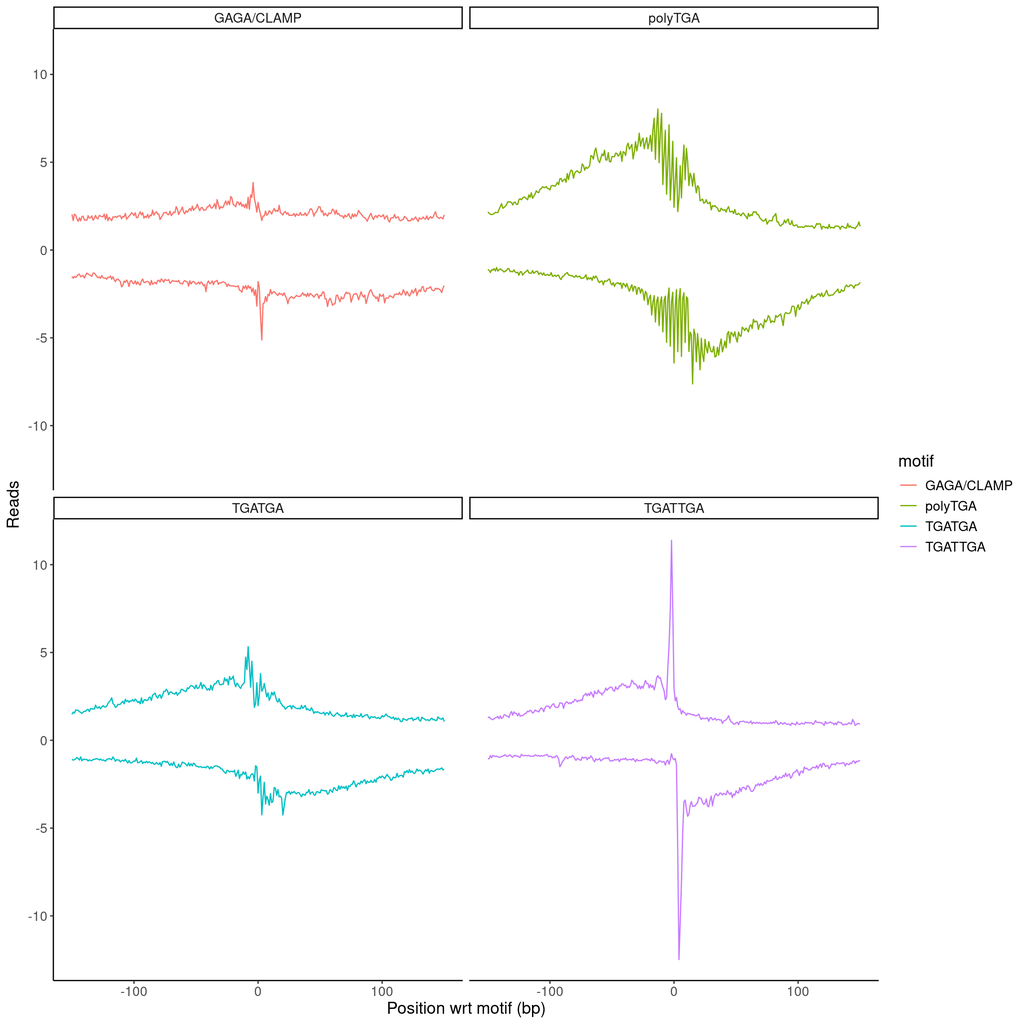

```r
alternate_mps.df<-lapply(all_alternate_motifs.gr$motif %>% unique, function(x){
  gr<-GenomicRanges::resize(all_alternate_motifs.gr %>%
                                                    plyranges::filter(motif==x),
                                                  width = 1, fix = 'center') %>%
    plyranges::arrange(desc(contrib_match)) %>%
    head(n=500)
  obs.df<-exo_metapeak(gr = gr,
                       sample = nexus_bw.list$S2_AntHOX6a_PBX_HA,
                       upstream = 150, downstream = 151) %>%
    dplyr::mutate(motif = x)
}) %>% rbindlist()

alternate_mp.plot<-ggplot(alternate_mps.df, aes(tss_distance, reads, group=interaction(motif,strand), color = motif))+
  geom_line()+
  scale_x_continuous(name = "Position wrt motif (bp)")+
  scale_y_continuous(name = "Reads")+
  theme_classic()+
  facet_wrap(~motif)+
  theme(text=element_text(size=14))
alternate_mp.plot
```

## Visualize PWMs and CWMs from TF-MoDISco

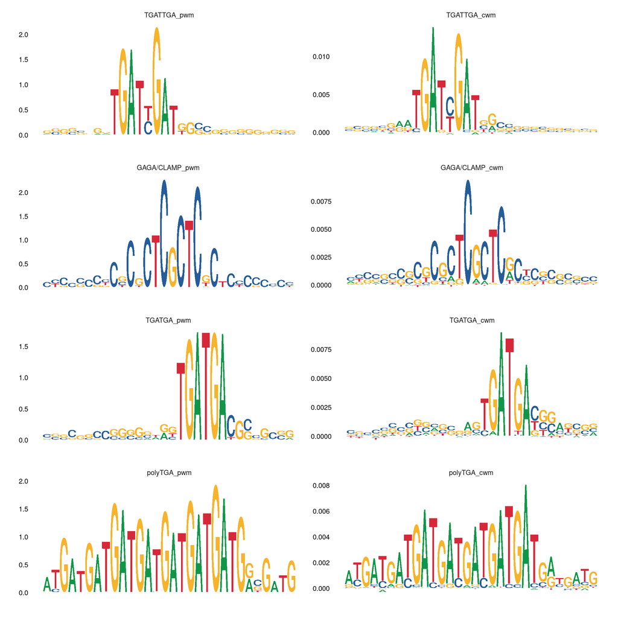

```r
# system(paste0('rm ', figure_filepath, '/unaligned_seqlets/seqlet_logo_*'))

#Plot all seqlet PWM and CWM logos
pwm_and_cwm.logo.list<-lapply(names(motifs.list), function(x){
  message(x)
  info.df<-motifs.list[[x]] %>% lapply(., function(y) data.frame(motif = y[1],
                                                                 oriented_strand = y[2])) %>%
    rbindlist(idcol = 'pattern_name')

  lapply(1:nrow(info.df), function(y){
    s.hdf5<-rhdf5::h5read(paste0('modiscolite/', x, '/modisco.h5'),
                          paste0('pos_patterns/', info.df$pattern_name[y]))
    cwm<-s.hdf5$contrib_scores
    pwm<-ppm_to_ic(s.hdf5$sequence, bg_freq = c(.3, .2, .2, .3))

    #Orient strand
    if(info.df$oriented_strand[y]=='neg'){
      cwm<-cwm[nrow(cwm):1,ncol(cwm):1]
      pwm<-pwm[nrow(pwm):1,ncol(pwm):1]
    }

    rownames(cwm)<-c('A','C','G','T')
    rownames(pwm)<-c('A','C','G','T')
    pwm_and_cwm.list<-list(pwm = pwm, cwm = cwm)
    y_prefix<-paste0(x %>% gsub('_fold1', '', .) %>% gsub('_pbx_counts', '', .) %>% gsub('_dfd_counts', '', .))
    names(pwm_and_cwm.list)<-paste0(info.df$motif[y], c('_pwm', '_cwm'))

    pwm_and_cwm.logo<-ggseqlogo(pwm_and_cwm.list, method='custom', seq_type='dna') +
      facet_wrap(~seq_group, nrow = 1, scales='free') +
      theme(axis.text.x = element_blank())
  }) %>% wrap_plots(ncol = 1)
})

pwm_and_cwm.logo.list
```

# Visualize alternative HOX motifs

## In vivo metapeaks

Given the different allowed affinities, how does each TF bind?

```r
candidates.vec<-c('TGATTGAT', 'TGATTAAT', 'TGATTTAT')

alternate_hox.df<-lapply(all_motifs.gr$model %>% unique %>% grep('anthox', ., value = T), function(x){
  message(x)
  m.gr<-all_motifs.gr %>% plyranges::filter(model==x)
  nexus_name<-grep(gsub('_nexus_fold1_pbx_counts', '', x), names(nexus_bw.list), value = T, ignore.case = T)

  all.df<-mclapply(candidates.vec, function(y){

    alt.gr<-m.gr %>% plyranges::filter(grepl(y, seq)) %>%
      # head(n=top_n) %>%
      plyranges::arrange(contrib_match)

    df<-exo_metapeak(gr = GenomicRanges::resize(alt.gr, width = 1, fix = 'center'), sample = nexus_bw.list[[nexus_name]],
                     upstream = 150, downstream = 151) %>%
      dplyr::mutate(seq = y, model = nexus_name, motif_count = length(alt.gr))
  }, mc.cores = 4) %>% rbindlist()
  return(all.df)
}) %>% rbindlist()

alternate_hox.df %>% dplyr::select(model, seq, motif_count) %>% unique()
```

```
##                    model      seq motif_count
##                   <char>   <char>       <int>
##  1: S2_AntHOX6a_PBX_Flag TGATTGAT        2762
##  2: S2_AntHOX6a_PBX_Flag TGATTAAT          23
##  3: S2_AntHOX6a_PBX_Flag TGATTTAT           6
##  4:   S2_AntHOX6a_PBX_HA TGATTGAT        5510
##  5:   S2_AntHOX6a_PBX_HA TGATTAAT         324
##  6:   S2_AntHOX6a_PBX_HA TGATTTAT         252
##  7: S2_AntHOX1a_PBX_Flag TGATTGAT        3933
##  8: S2_AntHOX1a_PBX_Flag TGATTAAT        2630
##  9: S2_AntHOX1a_PBX_Flag TGATTTAT        6186
## 10:   S2_AntHOX1a_PBX_HA TGATTGAT         457
## 11:   S2_AntHOX1a_PBX_HA TGATTAAT         363
## 12:   S2_AntHOX1a_PBX_HA TGATTTAT        2116
```

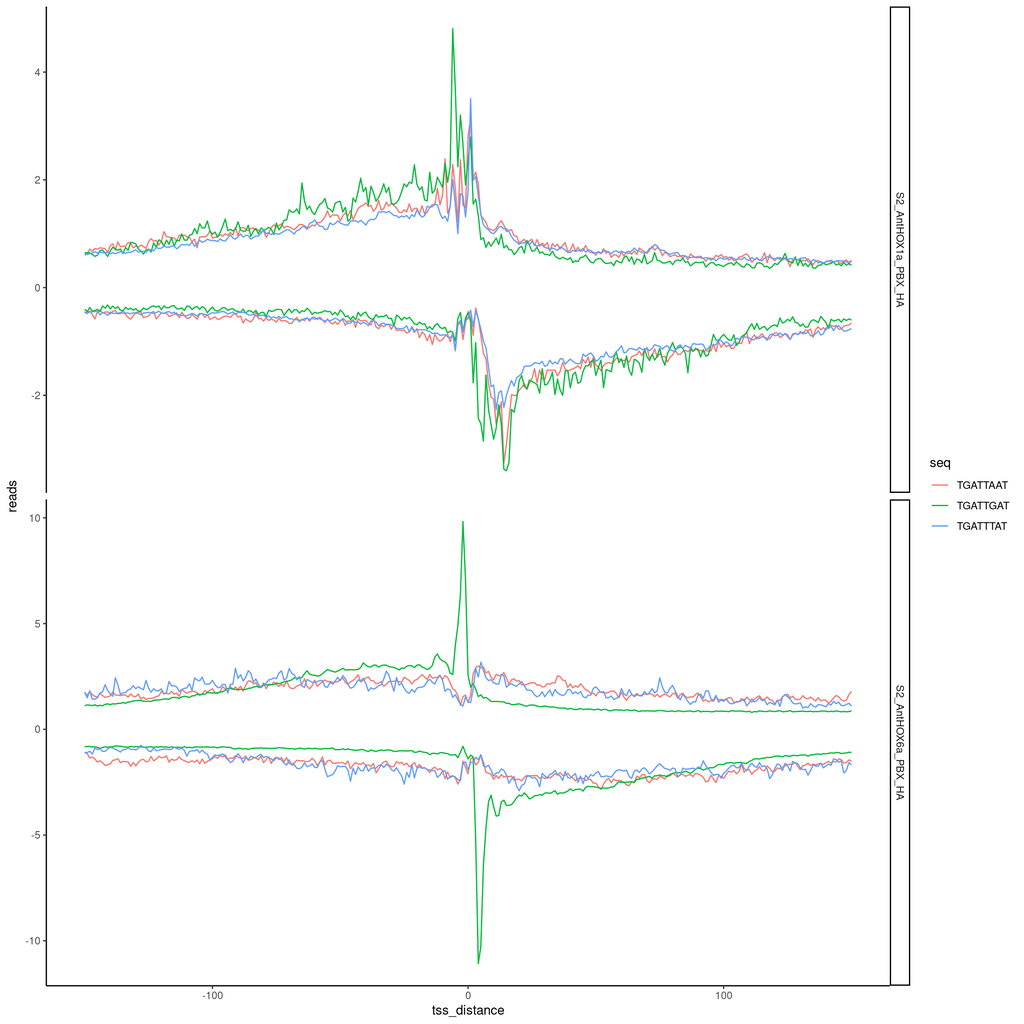

```r
metaplots.plot<-alternate_hox.df %>% dplyr::filter(!grepl('Flag', model)) %>%
  ggplot(., aes(x = tss_distance, y = reads, group = interaction(strand, seq), color = seq))+
  geom_line()+
  facet_grid(model ~ ., scales = 'free')+
  theme_classic()
metaplots.plot
```

Unexpected! But interesting. Are these regions more accessible in S2 cells?

## In silico marginalizations

```r
marg_raw.df<-Sys.glob('tsv/insilico/insilico_hox_marginalizations_s2_anthox*a_pbx_ha_nexus.tsv.gz') %>%
  lapply(., function(x) readr::read_tsv(x) %>% dplyr::mutate(tf = basename(x) %>% gsub('insilico_hox_marginalizations_s2_', '', .) %>% gsub('_pbx_ha_nexus.tsv.gz','',.))) %>%
  rbindlist()

marg.df<-marg_raw.df %>%
  dplyr::filter(seqA != 'none') %>%
  dplyr::rename(marg_inj = pbx) %>%
  dplyr::left_join(marg_raw.df %>% dplyr::filter(seqA=='none') %>% dplyr::rename(marg_null = pbx) %>% dplyr::select(marg_null, tf)) %>%
  dplyr::mutate(marg = marg_inj - marg_null)

marg.plot<-ggplot(marg.df, aes(x = tf, y = marg, fill = seqA))+
  geom_bar(stat = 'identity', position = 'dodge')+
  theme_classic()


plot<-metaplots.plot + marg.plot
ggsave(paste0(figure_filepath, '/affinity_checks.png'), plot, height = 6, width = 12)
ggsave(paste0(figure_filepath, '/affinity_checks.pdf'), plot, height = 6, width = 12)
```

Also show this for Flag condition.

```r
marg_raw.df<-Sys.glob('tsv/insilico/insilico_hox_marginalizations_s2_anthox*_nexus.tsv.gz') %>%
  lapply(., function(x) readr::read_tsv(x) %>% dplyr::mutate(tf = basename(x) %>% gsub('insilico_hox_marginalizations_s2_', '', .))) %>%
  rbindlist()

marg.df<-marg_raw.df %>%
  dplyr::filter(seqA != 'none') %>%
  dplyr::rename(marg_inj = pbx) %>%
  dplyr::left_join(marg_raw.df %>% dplyr::filter(seqA=='none') %>% dplyr::rename(marg_null = pbx) %>% dplyr::select(marg_null, tf)) %>%
  dplyr::mutate(marg = marg_inj - marg_null)

marg.plot<-ggplot(marg.df, aes(x = tf, y = marg, fill = seqA))+
  geom_bar(stat = 'identity', position = 'dodge')+
  theme_classic()

plot<-marg.plot
ggsave(paste0(figure_filepath, '/affinity_checks_w_all.png'), plot, height = 6, width =12)
ggsave(paste0(figure_filepath, '/affinity_checks_w_all.pdf'), plot, height = 6, width = 12)
```

# Conclusions

In conclusion, motifs were curated based on multiple redundancies and saved to 1-based and 0-based coordinates. These will be the reference motifs that we base subsequent analysis on.